# puretones

Brian C Leavell

2024-05-11

## Generating series of pure sine tones for use in ultrasonic propagation study

Details: This creates a series of pure (i.e. no frequency or amplitude modulation) sinusoidal tones that are based off the range of echolocation frequencies of species listed in the pdf “WesternUS_Acoustic_Table_Mar2011” by Joe Szewczak, Humboldt State University Bat Lab, June 2018. The series begins at 10 kHz, which is near the lower end of *Euderma maculatum*’s call. It continues in increments of 10 kHz (i.e. 10 kHz, 20 kHz, 30 khz, …) and ends at 100 kHz, which is near the upper end of *Myotis californicus*’s call. Each tone is 10 ms in duration, which is within the range of call durations from the aforementioned pdf.

```r
library(seewave)
```

Create files

- Settings:
- Pure tones in sequence (in Khz): 10, 20, 30, 40, 50, 60, 70, 80, 90, 100
- Sine waves
- Fade-in & Fade-out = None
- Sample rate = 250 kHz
- Bit depth = 16 (PCM)
- Duration = 0.19 sec (10 msec per tone, 10 msec silent interval between signals)

```r
kHz_10 <- synth(f = 250000,
                cf = 10000,
                d = 0.01,
                a = 1,
                signal = "sine",
                output = "Wave"
                )

kHz_20 <- synth(f = 250000,
                cf = 20000,
                d = 0.01,
                a = 1,
                signal = "sine",
                output = "Wave"
                )

kHz_30 <- synth(f = 250000,
                cf = 30000,
                d = 0.01,
                a = 1,
                signal = "sine",
                output = "Wave"
                )

kHz_40 <- synth(f = 250000,
                cf = 40000,
                d = 0.01,
                a = 1,
                signal = "sine",
                output = "Wave"
                )

kHz_50 <- synth(f = 250000,
                cf = 50000,
                d = 0.01,
                a = 1,
                signal = "sine",
                output = "Wave"
                )

kHz_60 <- synth(f = 250000,
                cf = 60000,
                d = 0.01,
                a = 1,
                signal = "sine",
                output = "Wave"
                )

kHz_70 <- synth(f = 250000,
                cf = 70000,
                d = 0.01,
                a = 1,
                signal = "sine",
                output = "Wave"
                )

kHz_80 <- synth(f = 250000,
                cf = 80000,
                d = 0.01,
                a = 1,
                signal = "sine",
                output = "Wave"
                )

kHz_90 <- synth(f = 250000,
                cf = 90000,
                d = 0.01,
                a = 1,
                signal = "sine",
                output = "Wave"
                )

kHz_100 <- synth(f = 250000,
                cf = 100000,
                d = 0.01,
                a = 1,
                signal = "sine",
                output = "Wave"
                )

#Add silence to each file (except kHz_100 since it is last)
kHz_10 <- addsilw(kHz_10, at = "end", d = 0.01, output = "Wave")
kHz_20 <- addsilw(kHz_20, at = "end", d = 0.01, output = "Wave")
kHz_30 <- addsilw(kHz_30, at = "end", d = 0.01, output = "Wave")
kHz_40 <- addsilw(kHz_40, at = "end", d = 0.01, output = "Wave")
kHz_50 <- addsilw(kHz_50, at = "end", d = 0.01, output = "Wave")
kHz_60 <- addsilw(kHz_60, at = "end", d = 0.01, output = "Wave")
kHz_70 <- addsilw(kHz_70, at = "end", d = 0.01, output = "Wave")
kHz_80 <- addsilw(kHz_80, at = "end", d = 0.01, output = "Wave")
kHz_90 <- addsilw(kHz_90, at = "end", d = 0.01, output = "Wave")

#Join audio files
a <- pastew(kHz_20, kHz_10, output = "Wave")
b <- pastew(kHz_30, a, output = "Wave")
c <- pastew(kHz_40, b, output = "Wave")
d <- pastew(kHz_50, c, output = "Wave")
e <- pastew(kHz_60, d, output = "Wave")
f <- pastew(kHz_70, e, output = "Wave")
g <- pastew(kHz_80, f, output = "Wave")
h <- pastew(kHz_90, g, output = "Wave")
puretones <- pastew(kHz_100, h, output = "Wave")

savewav(puretones, filename = "puretones.wav") #final file save as .wav
```

## Oscillogram

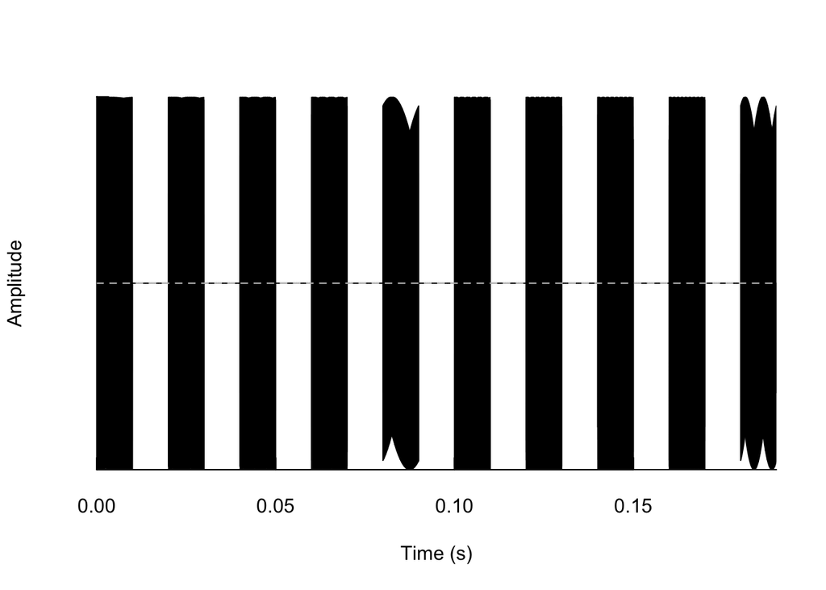

```r
oscillo(puretones)
```

## Power spectrum

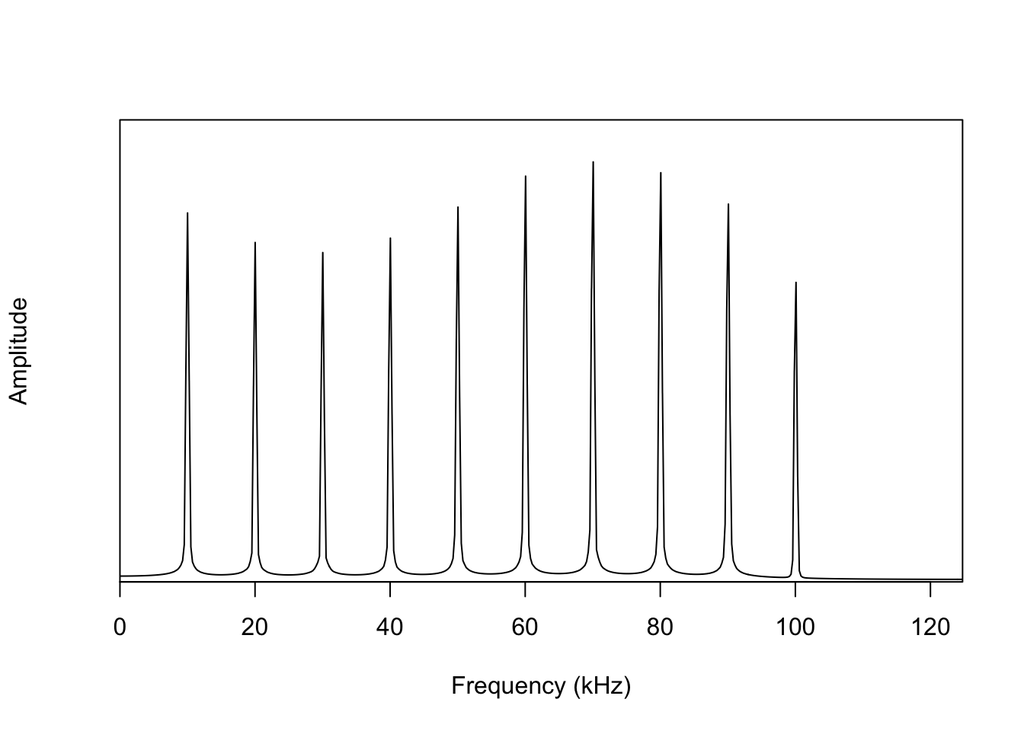

```r
meanspec(puretones,  wl = 1024)
```

## Spectrogram

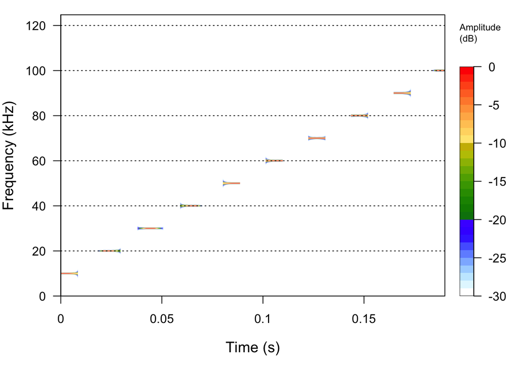

```r
spectro(puretones,  wl = 1024)
```

##References “WesternUS_Acoustic_Table_Mar2011” by Joe Szewczak, Humboldt State University Bat Lab, June 2018